# Daily-Level GAM Analysis of Monarch Butterfly Abundance

Author

Kyle Nessen

Published

September 29, 2025

## Introduction

This analysis investigates daily-level patterns in overwintering monarch butterfly abundance using Generalized Additive Models (GAMs). Unlike the 30-minute interval analysis, this approach aggregates data to daily summaries, examining how previous day’s weather conditions affect butterfly abundance. The response variable is the 95th percentile of butterfly counts, providing a robust measure of daily peak abundance while being less sensitive to outliers than the maximum.

## Setup

Load libraries and data:

```r
library(tidyverse)
library(mgcv)
library(lubridate)
library(plotly)
library(knitr)
library(DT)
library(here)
library(gratia)
library(patchwork)
library(corrplot)

# Load the daily lag analysis data
daily_data <- read_csv(here("data", "monarch_daily_lag_analysis.csv"))

# Create the square root transformed response variable early for use throughout
daily_data <- daily_data %>%
    mutate(
        butterfly_diff_95th_sqrt = ifelse(butterfly_diff_95th >= 0,
                                         sqrt(butterfly_diff_95th),
                                         -sqrt(-butterfly_diff_95th))
    )
```

## Data Exploration

### Data Structure and Summary

```r
# Basic summary statistics
cat("Dataset dimensions:", nrow(daily_data), "rows x", ncol(daily_data), "columns\n")
```

```
Dataset dimensions: 103 rows x 45 columns
```

```r
cat("Number of deployments:", n_distinct(daily_data$deployment_id), "\n")
```

```
Number of deployments: 7
```

```r
cat("Date range:", min(daily_data$date_t), "to", max(daily_data$date_t), "\n\n")
```

```
Date range: 19680 to 19756
```

```r
# Summary of key variables
summary_vars <- daily_data %>%
    select(
        butterflies_95th_percentile_t,
        butterflies_95th_percentile_t_1,
        butterfly_diff_95th,
        temp_max_t_1,
        temp_min_t_1,
        temp_at_max_count_t_1,
        wind_max_gust_t_1,
        sum_butterflies_direct_sun_t_1
    )

summary(summary_vars)
```

```
 butterflies_95th_percentile_t butterflies_95th_percentile_t_1
 Min.   :  0.00                Min.   :  0.0
 1st Qu.: 14.85                1st Qu.: 17.5
 Median : 70.05                Median : 77.0
 Mean   :107.41                Mean   :116.3
 3rd Qu.:166.95                3rd Qu.:199.5
 Max.   :499.00                Max.   :499.0

 butterfly_diff_95th  temp_max_t_1    temp_min_t_1    temp_at_max_count_t_1
 Min.   :-310.000    Min.   :14.00   Min.   : 3.000   Min.   : 5.00
 1st Qu.: -31.000    1st Qu.:16.00   1st Qu.: 7.000   1st Qu.:11.50
 Median :  -2.950    Median :18.00   Median :10.000   Median :14.00
 Mean   :  -8.919    Mean   :19.43   Mean   : 9.573   Mean   :13.37
 3rd Qu.:  18.000    3rd Qu.:22.00   3rd Qu.:12.000   3rd Qu.:15.50
 Max.   : 256.600    Max.   :37.00   Max.   :16.000   Max.   :25.00

 wind_max_gust_t_1 sum_butterflies_direct_sun_t_1
 Min.   :0.000     Min.   :   0.00
 1st Qu.:2.750     1st Qu.:   2.00
 Median :3.750     Median :  19.00
 Mean   :3.718     Mean   :  94.77
 3rd Qu.:4.500     3rd Qu.: 104.00
 Max.   :7.200     Max.   :1122.00
 NA's   :3
```

### Response Variable Distribution

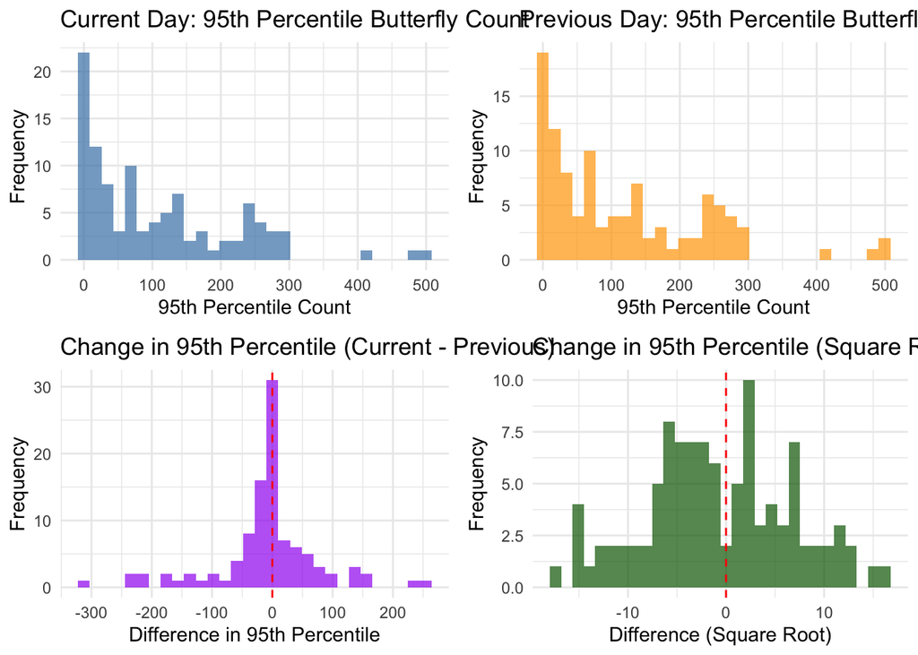

```r
library(gridExtra)

# Current day's 95th percentile
p1 <- ggplot(daily_data, aes(x = butterflies_95th_percentile_t)) +
    geom_histogram(bins = 30, fill = "steelblue", alpha = 0.7) +
    labs(
        title = "Current Day: 95th Percentile Butterfly Count",
        x = "95th Percentile Count", y = "Frequency"
    ) +
    theme_minimal()

# Previous day's 95th percentile
p2 <- ggplot(daily_data, aes(x = butterflies_95th_percentile_t_1)) +
    geom_histogram(bins = 30, fill = "orange", alpha = 0.7) +
    labs(
        title = "Previous Day: 95th Percentile Butterfly Count",
        x = "95th Percentile Count", y = "Frequency"
    ) +
    theme_minimal()

# Difference in 95th percentile
p3 <- ggplot(daily_data, aes(x = butterfly_diff_95th)) +
    geom_histogram(bins = 30, fill = "purple", alpha = 0.7) +
    geom_vline(xintercept = 0, linetype = "dashed", color = "red") +
    labs(
        title = "Change in 95th Percentile (Current - Previous)",
        x = "Difference in 95th Percentile", y = "Frequency"
    ) +
    theme_minimal()

# Square root transformed difference
p4 <- ggplot(daily_data, aes(x = butterfly_diff_95th_sqrt)) +
    geom_histogram(bins = 30, fill = "darkgreen", alpha = 0.7) +
    geom_vline(xintercept = 0, linetype = "dashed", color = "red") +
    labs(
        title = "Change in 95th Percentile (Square Root Transformed)",
        x = "Difference (Square Root)", y = "Frequency"
    ) +
    theme_minimal()

grid.arrange(p1, p2, p3, p4, ncol = 2)
```

### Correlation Analysis

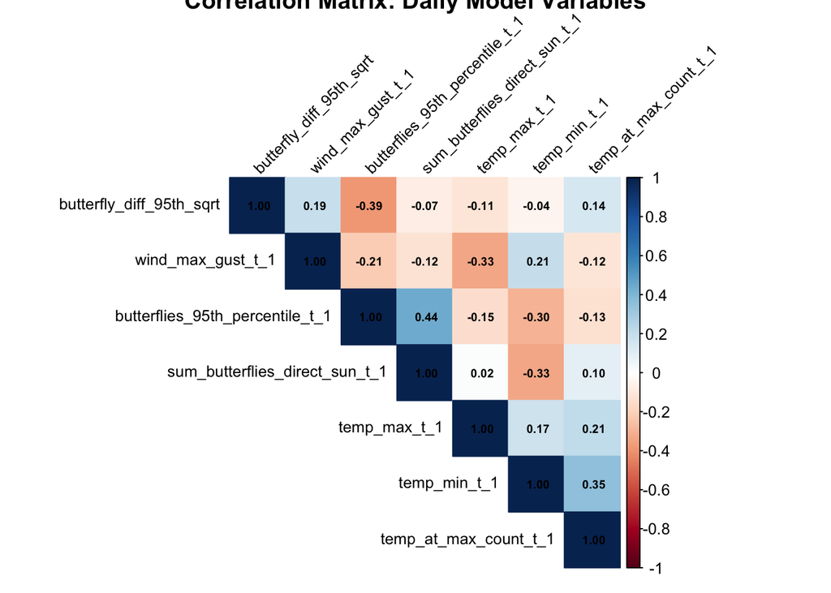

```r
# Select model variables
model_vars <- daily_data %>%
    select(
        butterfly_diff_95th_sqrt,
        butterflies_95th_percentile_t_1,
        temp_max_t_1,
        temp_min_t_1,
        temp_at_max_count_t_1,
        wind_max_gust_t_1,
        sum_butterflies_direct_sun_t_1
    ) %>%
    na.omit()

# Correlation matrix
cor_matrix <- cor(model_vars)

# Create correlation plot
corrplot(cor_matrix,
    method = "color",
    type = "upper",
    order = "hclust",
    tl.cex = 0.8,
    tl.col = "black",
    tl.srt = 45,
    addCoef.col = "black",
    number.cex = 0.6,
    title = "Correlation Matrix: Daily Model Variables"
)
```

```r
# Print correlation table
kable(round(cor_matrix, 3),
    caption = "Correlation Matrix for Daily Model Variables"
)
```

Correlation Matrix for Daily Model Variables

|  | butterfly_diff_95th_sqrt | butterflies_95th_percentile_t_1 | temp_max_t_1 | temp_min_t_1 | temp_at_max_count_t_1 | wind_max_gust_t_1 | sum_butterflies_direct_sun_t_1 |
| --- | --- | --- | --- | --- | --- | --- | --- |
| butterfly_diff_95th_sqrt | 1.000 | -0.389 | -0.112 | -0.042 | 0.145 | 0.193 | -0.072 |
| butterflies_95th_percentile_t_1 | -0.389 | 1.000 | -0.146 | -0.299 | -0.132 | -0.211 | 0.442 |
| temp_max_t_1 | -0.112 | -0.146 | 1.000 | 0.173 | 0.215 | -0.334 | 0.016 |
| temp_min_t_1 | -0.042 | -0.299 | 0.173 | 1.000 | 0.351 | 0.210 | -0.331 |
| temp_at_max_count_t_1 | 0.145 | -0.132 | 0.215 | 0.351 | 1.000 | -0.116 | 0.098 |
| wind_max_gust_t_1 | 0.193 | -0.211 | -0.334 | 0.210 | -0.116 | 1.000 | -0.122 |
| sum_butterflies_direct_sun_t_1 | -0.072 | 0.442 | 0.016 | -0.331 | 0.098 | -0.122 | 1.000 |

### Response Variable Normality Assessment

```r
library(nortest)

# First, identify all potential response variables in the dataset
response_candidates <- daily_data %>%
    select(contains("diff"), contains("butterfly")) %>%
    select(-contains("direct_sun")) %>%  # Remove non-response variables
    names()

cat("Available response variable candidates:\n")
```

```
Available response variable candidates:
```

```r
print(response_candidates)
```

```
 [1] "butterfly_diff"           "butterfly_diff_cbrt"
 [3] "butterfly_diff_log"       "butterfly_diff_95th"
 [5] "butterfly_diff_95th_cbrt" "butterfly_diff_95th_log"
 [7] "butterfly_diff_top3"      "butterfly_diff_top3_cbrt"
 [9] "butterfly_diff_top3_log"  "butterfly_diff_95th_sqrt"
```

```r
# Define transformations to test
transformations <- list(
    "original" = function(x) x,
    "sqrt" = function(x) ifelse(x >= 0, sqrt(x), -sqrt(-x)),  # Signed square root
    "fourth_root" = function(x) ifelse(x >= 0, x^0.25, -((-x)^0.25)),  # Signed fourth root
    "arcsinh" = function(x) asinh(x),  # Inverse hyperbolic sine (handles negative values)
    "yeo_johnson" = function(x) {
        # Simplified Yeo-Johnson transformation
        lambda <- 0.5
        ifelse(x >= 0,
               ((x + 1)^lambda - 1) / lambda,
               -(((-x) + 1)^(2-lambda) - 1) / (2-lambda))
    }
)

# Function to calculate normality statistics
assess_normality <- function(x, var_name, transform_name) {
    # Remove NA values
    x_clean <- x[!is.na(x)]

    if(length(x_clean) < 10) {
        return(data.frame(
            Variable = var_name,
            Transformation = transform_name,
            N = length(x_clean),
            Mean = NA,
            SD = NA,
            Skewness = NA,
            Kurtosis = NA,
            Shapiro_p = NA,
            Anderson_p = NA,
            Normality_Score = 0
        ))
    }

    # Calculate statistics
    mean_val <- mean(x_clean)
    sd_val <- sd(x_clean)
    skew_val <- moments::skewness(x_clean)
    kurt_val <- moments::kurtosis(x_clean) - 3  # Excess kurtosis

    # Normality tests
    shapiro_p <- if(length(x_clean) <= 5000) shapiro.test(x_clean)$p.value else NA
    anderson_p <- tryCatch(nortest::ad.test(x_clean)$p.value, error = function(e) NA)

    # Create composite normality score (higher = more normal)
    # Based on: low absolute skewness, low absolute kurtosis, high p-values
    skew_score <- max(0, 1 - abs(skew_val) / 2)  # Penalize skewness > 2
    kurt_score <- max(0, 1 - abs(kurt_val) / 4)  # Penalize excess kurtosis > 4
    shapiro_score <- ifelse(is.na(shapiro_p), 0.5, shapiro_p)
    anderson_score <- ifelse(is.na(anderson_p), 0.5, anderson_p)

    # Weighted composite score
    normality_score <- (skew_score * 0.3 + kurt_score * 0.3 +
                       shapiro_score * 0.2 + anderson_score * 0.2)

    return(data.frame(
        Variable = var_name,
        Transformation = transform_name,
        N = length(x_clean),
        Mean = round(mean_val, 3),
        SD = round(sd_val, 3),
        Skewness = round(skew_val, 3),
        Kurtosis = round(kurt_val, 3),
        Shapiro_p = ifelse(is.na(shapiro_p), NA, round(shapiro_p, 4)),
        Anderson_p = ifelse(is.na(anderson_p), NA, round(anderson_p, 4)),
        Normality_Score = round(normality_score, 4)
    ))
}

# Load required library for moments
library(moments)

# Apply transformations and assess normality for each response variable
normality_results <- list()

for(var_name in response_candidates) {
    if(var_name %in% names(daily_data)) {
        var_data <- daily_data[[var_name]]

        for(trans_name in names(transformations)) {
            trans_func <- transformations[[trans_name]]

            # Apply transformation
            transformed_data <- tryCatch(
                trans_func(var_data),
                error = function(e) rep(NA, length(var_data))
            )

            # Assess normality
            result <- assess_normality(transformed_data, var_name, trans_name)
            normality_results[[paste(var_name, trans_name, sep = "_")]] <- result
        }
    }
}

# Combine results
normality_df <- do.call(rbind, normality_results)

# Rank by normality score
normality_ranking <- normality_df %>%
    arrange(desc(Normality_Score)) %>%
    filter(!is.na(Normality_Score)) %>%
    mutate(Rank = row_number()) %>%
    select(Rank, Variable, Transformation, N, Mean, SD, Skewness, Kurtosis,
           Shapiro_p, Anderson_p, Normality_Score)

# Display top 15 most normal distributions
cat("Top 15 most normal response variable transformations:\n\n")
```

```
Top 15 most normal response variable transformations:
```

```r
kable(head(normality_ranking, 15),
      caption = "Response variables ranked by normality (higher score = more normal)")
```

Response variables ranked by normality (higher score = more normal)

|  | Rank | Variable | Transformation | N | Mean | SD | Skewness | Kurtosis | Shapiro_p | Anderson_p | Normality_Score |
| --- | --- | --- | --- | --- | --- | --- | --- | --- | --- | --- | --- |
| butterfly_diff_95th_sqrt | 1 | butterfly_diff_95th | sqrt | 103 | -0.809 | 7.382 | 0.021 | -0.467 | 0.6501 | 0.5918 | 0.8102 |
| butterfly_diff_95th_sqrt_original | 2 | butterfly_diff_95th_sqrt | original | 103 | -0.809 | 7.382 | 0.021 | -0.467 | 0.6501 | 0.5918 | 0.8102 |
| butterfly_diff_top3_sqrt | 3 | butterfly_diff_top3 | sqrt | 103 | -0.751 | 7.379 | 0.039 | -0.436 | 0.6273 | 0.5818 | 0.8033 |
| butterfly_diff_sqrt | 4 | butterfly_diff | sqrt | 103 | -1.148 | 8.033 | 0.238 | -0.117 | 0.6179 | 0.3799 | 0.7552 |
| butterfly_diff_top3_cbrt_original | 5 | butterfly_diff_top3_cbrt | original | 103 | -0.345 | 3.505 | 0.097 | -1.223 | 0.0004 | 0.0000 | 0.4938 |
| butterfly_diff_95th_cbrt_original | 6 | butterfly_diff_95th_cbrt | original | 103 | -0.393 | 3.502 | 0.129 | -1.212 | 0.0004 | 0.0000 | 0.4898 |
| butterfly_diff_cbrt_original | 7 | butterfly_diff_cbrt | original | 103 | -0.586 | 3.678 | 0.279 | -1.063 | 0.0005 | 0.0000 | 0.4786 |
| butterfly_diff_cbrt_yeo_johnson | 8 | butterfly_diff_cbrt | yeo_johnson | 103 | -2.465 | 4.671 | -0.602 | -0.503 | 0.0000 | 0.0000 | 0.4720 |
| butterfly_diff_top3_log_original | 9 | butterfly_diff_top3_log | original | 103 | -0.340 | 3.506 | 0.123 | -1.472 | 0.0000 | 0.0000 | 0.4711 |
| butterfly_diff_top3_fourth_root | 10 | butterfly_diff_top3 | fourth_root | 103 | -0.236 | 2.475 | 0.121 | -1.527 | 0.0000 | 0.0000 | 0.4672 |
| butterfly_diff_95th_log_original | 11 | butterfly_diff_95th_log | original | 103 | -0.394 | 3.505 | 0.171 | -1.455 | 0.0000 | 0.0000 | 0.4653 |
| butterfly_diff_top3_arcsinh | 12 | butterfly_diff_top3 | arcsinh | 103 | -0.392 | 4.105 | 0.129 | -1.560 | 0.0000 | 0.0000 | 0.4636 |
| butterfly_diff_log_yeo_johnson | 13 | butterfly_diff_log | yeo_johnson | 103 | -2.458 | 4.450 | -0.275 | -1.289 | 0.0000 | 0.0000 | 0.4621 |
| butterfly_diff_95th_fourth_root | 14 | butterfly_diff_95th | fourth_root | 103 | -0.279 | 2.470 | 0.168 | -1.505 | 0.0000 | 0.0000 | 0.4619 |
| butterfly_diff_95th_sqrt_sqrt | 15 | butterfly_diff_95th_sqrt | sqrt | 103 | -0.279 | 2.470 | 0.168 | -1.505 | 0.0000 | 0.0000 | 0.4619 |

```r
# Create summary by variable
variable_summary <- normality_ranking %>%
    group_by(Variable) %>%
    slice_max(Normality_Score, n = 1) %>%
    ungroup() %>%
    arrange(desc(Normality_Score)) %>%
    select(Variable, Best_Transformation = Transformation, Best_Score = Normality_Score,
           Skewness, Kurtosis, Shapiro_p)

cat("\n\nBest transformation for each response variable:\n")
```

```
Best transformation for each response variable:
```

```r
kable(variable_summary,
      caption = "Best transformation for each response variable")
```

Best transformation for each response variable

| Variable | Best_Transformation | Best_Score | Skewness | Kurtosis | Shapiro_p |
| --- | --- | --- | --- | --- | --- |
| butterfly_diff_95th | sqrt | 0.8102 | 0.021 | -0.467 | 0.6501 |
| butterfly_diff_95th_sqrt | original | 0.8102 | 0.021 | -0.467 | 0.6501 |
| butterfly_diff_top3 | sqrt | 0.8033 | 0.039 | -0.436 | 0.6273 |
| butterfly_diff | sqrt | 0.7552 | 0.238 | -0.117 | 0.6179 |
| butterfly_diff_top3_cbrt | original | 0.4938 | 0.097 | -1.223 | 0.0004 |
| butterfly_diff_95th_cbrt | original | 0.4898 | 0.129 | -1.212 | 0.0004 |
| butterfly_diff_cbrt | original | 0.4786 | 0.279 | -1.063 | 0.0005 |
| butterfly_diff_top3_log | original | 0.4711 | 0.123 | -1.472 | 0.0000 |
| butterfly_diff_95th_log | original | 0.4653 | 0.171 | -1.455 | 0.0000 |
| butterfly_diff_log | yeo_johnson | 0.4621 | -0.275 | -1.289 | 0.0000 |

```r
cat("\n\nUsing the best response variable transformation: butterfly_diff_95th_sqrt\n")
```

```
Using the best response variable transformation: butterfly_diff_95th_sqrt
```

```r
cat("Summary of transformed response variable:\n")
```

```
Summary of transformed response variable:
```

```r
print(summary(daily_data$butterfly_diff_95th_sqrt))
```

```
    Min.  1st Qu.   Median     Mean  3rd Qu.     Max.
-17.6068  -5.5649  -1.7176  -0.8088   4.2426  16.0187
```

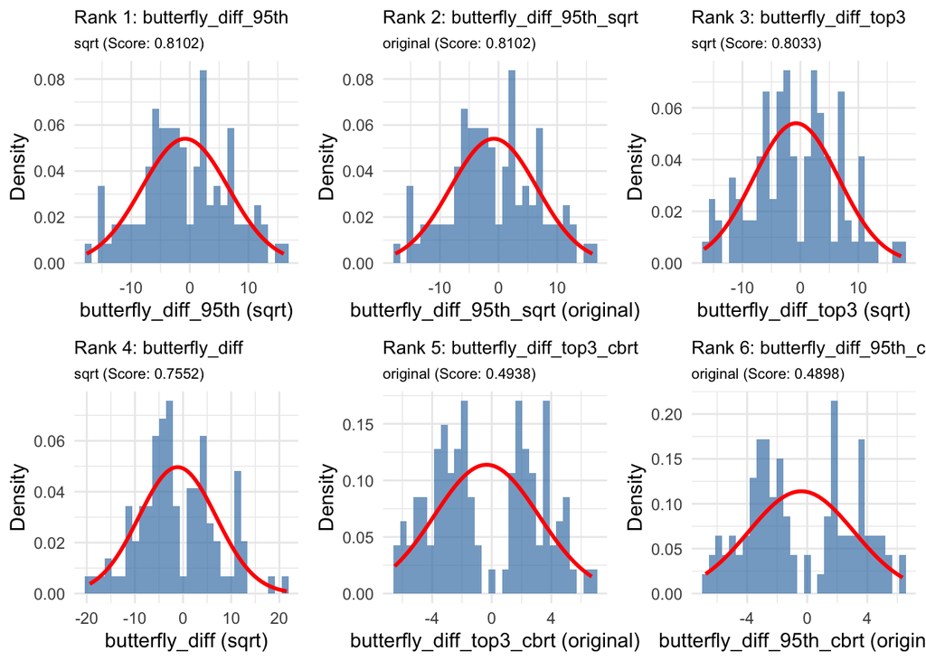

```r
# Visualize the top 6 most normal transformations
top_transformations <- head(normality_ranking, 6)

plots <- list()
for(i in 1:nrow(top_transformations)) {
    row <- top_transformations[i, ]
    var_name <- row$Variable
    trans_name <- row$Transformation

    if(var_name %in% names(daily_data)) {
        var_data <- daily_data[[var_name]]
        trans_func <- transformations[[trans_name]]
        transformed_data <- trans_func(var_data)

        # Create histogram with normal overlay
        p <- ggplot(data.frame(x = transformed_data), aes(x = x)) +
            geom_histogram(aes(y = after_stat(density)), bins = 30,
                          fill = "steelblue", alpha = 0.7) +
            stat_function(fun = dnorm,
                         args = list(mean = mean(transformed_data, na.rm = TRUE),
                                   sd = sd(transformed_data, na.rm = TRUE)),
                         color = "red", size = 1) +
            labs(
                title = paste0("Rank ", i, ": ", var_name),
                subtitle = paste0(trans_name, " (Score: ", row$Normality_Score, ")"),
                x = paste0(var_name, " (", trans_name, ")"),
                y = "Density"
            ) +
            theme_minimal() +
            theme(plot.title = element_text(size = 10),
                  plot.subtitle = element_text(size = 8))

        plots[[i]] <- p
    }
}

# Arrange plots in grid
if(length(plots) >= 6) {
    grid.arrange(plots[[1]], plots[[2]], plots[[3]],
                plots[[4]], plots[[5]], plots[[6]], ncol = 3)
} else {
    do.call(grid.arrange, c(plots, ncol = 3))
}
```

### Temperature Patterns

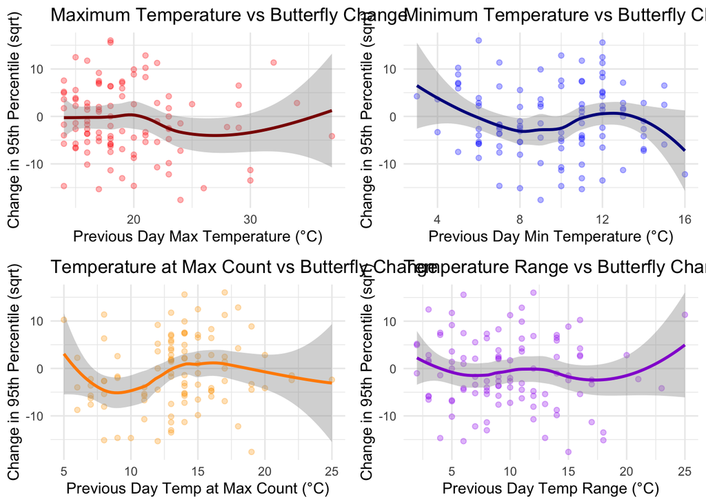

```r
# Temperature relationships
p1 <- ggplot(daily_data, aes(x = temp_max_t_1, y = butterfly_diff_95th_sqrt)) +
    geom_point(alpha = 0.3, color = "red") +
    geom_smooth(method = "loess", se = TRUE, color = "darkred") +
    labs(
        title = "Maximum Temperature vs Butterfly Change",
        x = "Previous Day Max Temperature (°C)",
        y = "Change in 95th Percentile (sqrt)"
    ) +
    theme_minimal()

p2 <- ggplot(daily_data, aes(x = temp_min_t_1, y = butterfly_diff_95th_sqrt)) +
    geom_point(alpha = 0.3, color = "blue") +
    geom_smooth(method = "loess", se = TRUE, color = "darkblue") +
    labs(
        title = "Minimum Temperature vs Butterfly Change",
        x = "Previous Day Min Temperature (°C)",
        y = "Change in 95th Percentile (sqrt)"
    ) +
    theme_minimal()

p3 <- ggplot(daily_data, aes(x = temp_at_max_count_t_1, y = butterfly_diff_95th_sqrt)) +
    geom_point(alpha = 0.3, color = "orange") +
    geom_smooth(method = "loess", se = TRUE, color = "darkorange") +
    labs(
        title = "Temperature at Max Count vs Butterfly Change",
        x = "Previous Day Temp at Max Count (°C)",
        y = "Change in 95th Percentile (sqrt)"
    ) +
    theme_minimal()

# Temperature range
daily_data <- daily_data %>%
    mutate(temp_range_t_1 = temp_max_t_1 - temp_min_t_1)

p4 <- ggplot(daily_data, aes(x = temp_range_t_1, y = butterfly_diff_95th_sqrt)) +
    geom_point(alpha = 0.3, color = "purple") +
    geom_smooth(method = "loess", se = TRUE, color = "darkviolet") +
    labs(
        title = "Temperature Range vs Butterfly Change",
        x = "Previous Day Temp Range (°C)",
        y = "Change in 95th Percentile (sqrt)"
    ) +
    theme_minimal()

grid.arrange(p1, p2, p3, p4, ncol = 2)
```

### Wind and Sun Exposure

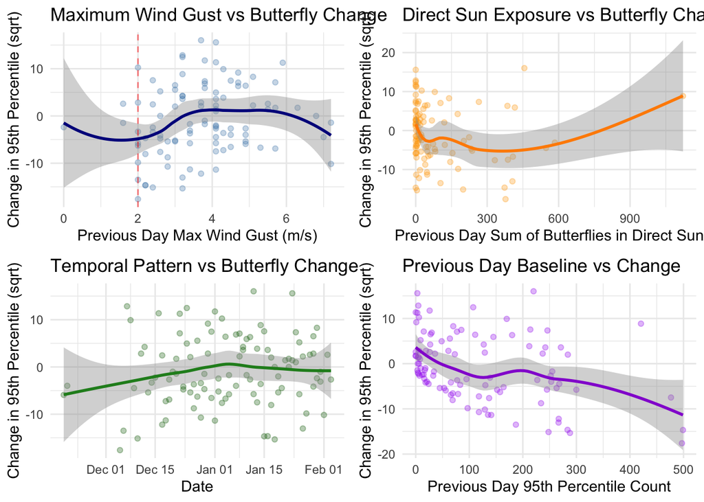

```r
# Wind effect
p1 <- ggplot(daily_data, aes(x = wind_max_gust_t_1, y = butterfly_diff_95th_sqrt)) +
    geom_point(alpha = 0.3, color = "steelblue") +
    geom_smooth(method = "loess", se = TRUE, color = "darkblue") +
    geom_vline(xintercept = 2, linetype = "dashed", color = "red", alpha = 0.5) +
    labs(
        title = "Maximum Wind Gust vs Butterfly Change",
        x = "Previous Day Max Wind Gust (m/s)",
        y = "Change in 95th Percentile (sqrt)"
    ) +
    theme_minimal()

# Sun exposure
p2 <- ggplot(daily_data, aes(x = sum_butterflies_direct_sun_t_1, y = butterfly_diff_95th_sqrt)) +
    geom_point(alpha = 0.3, color = "orange") +
    geom_smooth(method = "loess", se = TRUE, color = "darkorange") +
    labs(
        title = "Direct Sun Exposure vs Butterfly Change",
        x = "Previous Day Sum of Butterflies in Direct Sun",
        y = "Change in 95th Percentile (sqrt)"
    ) +
    theme_minimal()

# Note: Seasonal progression will be handled via temporal autocorrelation
# rather than as a fixed effect
p3 <- ggplot(daily_data, aes(x = date_t, y = butterfly_diff_95th_sqrt)) +
    geom_point(alpha = 0.3, color = "darkgreen") +
    geom_smooth(method = "loess", se = TRUE, color = "forestgreen") +
    labs(
        title = "Temporal Pattern vs Butterfly Change",
        x = "Date",
        y = "Change in 95th Percentile (sqrt)"
    ) +
    theme_minimal()

# Previous day baseline
p4 <- ggplot(daily_data, aes(x = butterflies_95th_percentile_t_1, y = butterfly_diff_95th_sqrt)) +
    geom_point(alpha = 0.3, color = "purple") +
    geom_smooth(method = "loess", se = TRUE, color = "darkviolet") +
    labs(
        title = "Previous Day Baseline vs Change",
        x = "Previous Day 95th Percentile Count",
        y = "Change in 95th Percentile (sqrt)"
    ) +
    theme_minimal()

grid.arrange(p1, p2, p3, p4, ncol = 2)
```

## Data Preparation

```r
# Remove missing values and prepare modeling dataset
model_data <- daily_data %>%
    filter(
        !is.na(butterfly_diff_95th_sqrt),
        !is.na(butterflies_95th_percentile_t_1),
        !is.na(temp_max_t_1),
        !is.na(temp_min_t_1),
        !is.na(temp_at_max_count_t_1),
        !is.na(wind_max_gust_t_1),
        !is.na(sum_butterflies_direct_sun_t_1),
        !is.na(deployment_id)
    ) %>%
    # Create standardized versions for interpretation
    mutate(
        wind_max_gust_std = scale(wind_max_gust_t_1)[, 1],
        temp_max_std = scale(temp_max_t_1)[, 1],
        temp_min_std = scale(temp_min_t_1)[, 1],
        temp_at_max_std = scale(temp_at_max_count_t_1)[, 1],
        sun_exposure_std = scale(sum_butterflies_direct_sun_t_1)[, 1],
        baseline_std = scale(butterflies_95th_percentile_t_1)[, 1],
        # Create a day sequence for temporal autocorrelation
        day_sequence = as.numeric(date_t - min(date_t)) + 1
    )

cat("Clean dataset has", nrow(model_data), "observations\n")
```

```
Clean dataset has 100 observations
```

```r
cat("Number of unique deployment days:", n_distinct(paste(model_data$deployment_id, model_data$date_t)), "\n")
```

```
Number of unique deployment days: 100
```

## Modeling Strategy

Our modeling approach for daily-level data tests the **absolute effects** of environmental variables on butterfly abundance changes:

1. **Response Variable**: `butterfly_diff_95th_sqrt` - square root transformed difference in 95th percentile butterfly counts between consecutive days (selected as the most normal transformation)
2. **Fixed Effects** (WITHOUT controlling for previous day’s abundance):
   - Temperature variables: max, min, and temperature at max count (testing various combinations)
   - Wind: maximum gust from previous day
   - Sun exposure: sum of butterflies in direct sun from previous day
3. **Random Effects**:
   - Deployment ID (random intercept)
   - Temporal autocorrelation structure to account for time-dependent patterns

**Note**: This analysis deliberately excludes the previous day’s butterfly count (`butterflies_95th_percentile_t_1`) to test whether environmental variables have direct effects on absolute changes in abundance, rather than proportional effects after controlling for baseline levels.

## Model Building and Selection

```r
library(nlme)

# Define random effects structure with temporal autocorrelation
# We'll test different correlation structures
random_structure <- list(deployment_id = ~1)

# Define correlation structures to test
# AR1: First-order autoregressive (adjacent days are correlated)
# ARMA: Autoregressive moving average
correlation_structures <- list(
    "no_corr" = NULL,  # No temporal correlation (baseline)
    "ar1" = corAR1(form = ~day_sequence | deployment_id),  # AR(1) within deployment
    "ar1_compound" = corCompSymm(form = ~day_sequence | deployment_id)  # Compound symmetry
)

# Model specifications for AIC comparison - WITHOUT previous day baseline
model_specs <- list(
    # Null model
    "M1" = "butterfly_diff_95th_sqrt ~ 1",

    # Single predictor models (linear)
    "M2" = "butterfly_diff_95th_sqrt ~ wind_max_gust_t_1",
    "M3" = "butterfly_diff_95th_sqrt ~ temp_max_t_1",
    "M4" = "butterfly_diff_95th_sqrt ~ temp_min_t_1",
    "M5" = "butterfly_diff_95th_sqrt ~ temp_at_max_count_t_1",
    "M6" = "butterfly_diff_95th_sqrt ~ sum_butterflies_direct_sun_t_1",

    # Temperature combinations (linear)
    "M8" = "butterfly_diff_95th_sqrt ~ temp_max_t_1 + temp_min_t_1",
    "M9" = "butterfly_diff_95th_sqrt ~ temp_max_t_1 + temp_at_max_count_t_1",
    "M10" = "butterfly_diff_95th_sqrt ~ temp_min_t_1 + temp_at_max_count_t_1",
    "M11" = "butterfly_diff_95th_sqrt ~ temp_max_t_1 + temp_min_t_1 + temp_at_max_count_t_1",

    # Two-variable combinations
    "M12" = "butterfly_diff_95th_sqrt ~ wind_max_gust_t_1 + temp_max_t_1",
    "M13" = "butterfly_diff_95th_sqrt ~ wind_max_gust_t_1 + temp_min_t_1",
    "M14" = "butterfly_diff_95th_sqrt ~ wind_max_gust_t_1 + temp_at_max_count_t_1",
    "M15" = "butterfly_diff_95th_sqrt ~ wind_max_gust_t_1 + sum_butterflies_direct_sun_t_1",
    "M16" = "butterfly_diff_95th_sqrt ~ temp_at_max_count_t_1 + sum_butterflies_direct_sun_t_1",

    # Full models with various temperature specs (linear)
    "M17" = "butterfly_diff_95th_sqrt ~ temp_max_t_1 + wind_max_gust_t_1 + sum_butterflies_direct_sun_t_1",
    "M18" = "butterfly_diff_95th_sqrt ~ temp_min_t_1 + wind_max_gust_t_1 + sum_butterflies_direct_sun_t_1",
    "M19" = "butterfly_diff_95th_sqrt ~ temp_at_max_count_t_1 + wind_max_gust_t_1 + sum_butterflies_direct_sun_t_1",
    "M20" = "butterfly_diff_95th_sqrt ~ temp_max_t_1 + temp_min_t_1 + wind_max_gust_t_1 + sum_butterflies_direct_sun_t_1",
    "M21" = "butterfly_diff_95th_sqrt ~ temp_max_t_1 + temp_min_t_1 + temp_at_max_count_t_1 + wind_max_gust_t_1 + sum_butterflies_direct_sun_t_1",

    # Smooth terms models - single predictors
    "M24" = "butterfly_diff_95th_sqrt ~ s(wind_max_gust_t_1)",
    "M25" = "butterfly_diff_95th_sqrt ~ s(temp_max_t_1)",
    "M26" = "butterfly_diff_95th_sqrt ~ s(temp_min_t_1)",
    "M27" = "butterfly_diff_95th_sqrt ~ s(temp_at_max_count_t_1)",
    "M28" = "butterfly_diff_95th_sqrt ~ s(sum_butterflies_direct_sun_t_1)",

    # Smooth terms - combinations
    "M30" = "butterfly_diff_95th_sqrt ~ s(temp_max_t_1) + s(temp_min_t_1)",
    "M31" = "butterfly_diff_95th_sqrt ~ s(temp_at_max_count_t_1) + s(wind_max_gust_t_1)",
    "M32" = "butterfly_diff_95th_sqrt ~ s(temp_at_max_count_t_1) + s(sum_butterflies_direct_sun_t_1)",
    "M33" = "butterfly_diff_95th_sqrt ~ s(wind_max_gust_t_1) + s(sum_butterflies_direct_sun_t_1)",

    # Complex smooth models
    "M34" = "butterfly_diff_95th_sqrt ~ s(temp_at_max_count_t_1) + s(wind_max_gust_t_1) + s(sum_butterflies_direct_sun_t_1)",
    "M35" = "butterfly_diff_95th_sqrt ~ s(temp_max_t_1) + s(temp_min_t_1) + s(wind_max_gust_t_1) + s(sum_butterflies_direct_sun_t_1)",
    "M36" = "butterfly_diff_95th_sqrt ~ s(temp_at_max_count_t_1) + s(wind_max_gust_t_1) + s(sum_butterflies_direct_sun_t_1)",
    "M37" = "butterfly_diff_95th_sqrt ~ s(temp_max_t_1) + s(temp_min_t_1) + s(temp_at_max_count_t_1) + s(wind_max_gust_t_1) + s(sum_butterflies_direct_sun_t_1)",

    # Mixed linear and smooth
    "M38" = "butterfly_diff_95th_sqrt ~ temp_at_max_count_t_1 + s(wind_max_gust_t_1) + s(sum_butterflies_direct_sun_t_1)",
    "M39" = "butterfly_diff_95th_sqrt ~ s(temp_at_max_count_t_1) + wind_max_gust_t_1 + sum_butterflies_direct_sun_t_1",
    "M40" = "butterfly_diff_95th_sqrt ~ s(temp_at_max_count_t_1) + wind_max_gust_t_1 + s(sum_butterflies_direct_sun_t_1)",

    # Interaction models (without baseline)
    "M41" = "butterfly_diff_95th_sqrt ~ temp_at_max_count_t_1 * wind_max_gust_t_1",
    "M42" = "butterfly_diff_95th_sqrt ~ temp_at_max_count_t_1 * sum_butterflies_direct_sun_t_1",
    "M43" = "butterfly_diff_95th_sqrt ~ wind_max_gust_t_1 * sum_butterflies_direct_sun_t_1",
    "M44" = "butterfly_diff_95th_sqrt ~ temp_at_max_count_t_1 * wind_max_gust_t_1 + sum_butterflies_direct_sun_t_1",
    "M45" = "butterfly_diff_95th_sqrt ~ temp_at_max_count_t_1 + wind_max_gust_t_1 * sum_butterflies_direct_sun_t_1",
    "M46" = "butterfly_diff_95th_sqrt ~ temp_at_max_count_t_1 * wind_max_gust_t_1 * sum_butterflies_direct_sun_t_1",

    # Temperature range models
    "M47" = "butterfly_diff_95th_sqrt ~ I(temp_max_t_1 - temp_min_t_1)",
    "M48" = "butterfly_diff_95th_sqrt ~ I(temp_max_t_1 - temp_min_t_1) + wind_max_gust_t_1",
    "M49" = "butterfly_diff_95th_sqrt ~ s(I(temp_max_t_1 - temp_min_t_1))",
    "M50" = "butterfly_diff_95th_sqrt ~ s(I(temp_max_t_1 - temp_min_t_1)) + s(wind_max_gust_t_1)"
)

cat("Total models to fit (WITHOUT previous day baseline):", length(model_specs), "\n")
```

```
Total models to fit (WITHOUT previous day baseline): 46
```

## Model Fitting

```r
# Function to safely fit models with correlation structures
fit_model_safely <- function(formula_str, data, correlation = NULL, corr_name = "no_corr") {
    tryCatch(
        {
            formula_obj <- as.formula(formula_str)

            # Fit the model with or without correlation structure
            if (is.null(correlation)) {
                model <- gamm(formula_obj,
                    data = data,
                    random = random_structure,
                    method = "REML"
                )
            } else {
                model <- gamm(formula_obj,
                    data = data,
                    random = random_structure,
                    correlation = correlation,
                    method = "REML"
                )
            }

            # Add correlation structure name to the model for tracking
            model$correlation_structure <- corr_name
            return(model)
        },
        error = function(e) {
            message("Failed to fit model: ", formula_str, " with correlation: ", corr_name)
            message("Error: ", e$message)
            return(NULL)
        }
    )
}

# Fit all models with different correlation structures
cat("Fitting models with different correlation structures...\n")
```

```
Fitting models with different correlation structures...
```

```r
fitted_models <- list()

# For each model specification, fit with each correlation structure
model_counter <- 1
for (model_name in names(model_specs)) {
    formula_str <- model_specs[[model_name]]

    for (corr_name in names(correlation_structures)) {
        corr_struct <- correlation_structures[[corr_name]]

        # Create unique model name combining formula and correlation structure
        full_model_name <- paste0(model_name, "_", corr_name)

        # Fit the model
        fitted_models[[full_model_name]] <- fit_model_safely(
            formula_str, model_data, corr_struct, corr_name
        )

        model_counter <- model_counter + 1
    }
}

# Remove failed models
successful_models <- fitted_models[!map_lgl(fitted_models, is.null)]
cat("Successfully fitted", length(successful_models), "out of",
    length(model_specs) * length(correlation_structures), "model-correlation combinations\n")
```

```
Successfully fitted 138 out of 138 model-correlation combinations
```

## Model Comparison

```r
# Extract AIC values
aic_results <- map_dfr(names(successful_models), function(full_model_name) {
    model <- successful_models[[full_model_name]]

    # Extract base model name and correlation structure
    parts <- strsplit(full_model_name, "_")[[1]]
    # The correlation name is the last part after the final underscore
    n_parts <- length(parts)
    if (n_parts >= 2) {
        corr_name <- parts[n_parts]
        base_model_name <- paste(parts[-n_parts], collapse = "_")
    } else {
        corr_name <- "no_corr"
        base_model_name <- full_model_name
    }

    # Get the formula from the base model name
    formula_str <- model_specs[[base_model_name]]
    if (is.null(formula_str)) {
        # Handle edge case where base model name doesn't match exactly
        formula_str <- "Unknown formula"
    }

    data.frame(
        Model = full_model_name,
        Base_Model = base_model_name,
        Formula = formula_str,
        Correlation = corr_name,
        AIC = AIC(model$lme),
        LogLik = logLik(model$lme)[1],
        df = attr(logLik(model$lme), "df"),
        stringsAsFactors = FALSE
    )
}) %>%
    arrange(AIC) %>%
    mutate(
        Delta_AIC = AIC - min(AIC),
        AIC_weight = exp(-0.5 * Delta_AIC) / sum(exp(-0.5 * Delta_AIC))
    )

# Display top 10 models
aic_results %>%
    head(10) %>%
    select(Model, Correlation, AIC, Delta_AIC, AIC_weight, df) %>%
    kable(digits = 3, caption = "Top 10 models by AIC (including correlation structure)")
```

Top 10 models by AIC (including correlation structure)

| Model | Correlation | AIC | Delta_AIC | AIC_weight | df |
| --- | --- | --- | --- | --- | --- |
| M34_ar1 | ar1 | 682.468 | 0.000 | 0.108 | 10 |
| M36_ar1 | ar1 | 682.468 | 0.000 | 0.108 | 10 |
| M33_ar1 | ar1 | 682.524 | 0.056 | 0.105 | 8 |
| M38_ar1 | ar1 | 683.142 | 0.674 | 0.077 | 9 |
| M28_ar1 | ar1 | 683.501 | 1.033 | 0.065 | 6 |
| M37_ar1 | ar1 | 683.909 | 1.441 | 0.053 | 14 |
| M40_ar1 | ar1 | 684.639 | 2.171 | 0.037 | 9 |
| M34_no_corr | corr | 684.934 | 2.466 | 0.032 | 9 |
| M36_no_corr | corr | 684.934 | 2.466 | 0.032 | 9 |
| M32_ar1 | ar1 | 685.164 | 2.696 | 0.028 | 8 |

```r
# Show model formulas for top 5
cat("\nTop 5 model specifications:\n")
```

```
Top 5 model specifications:
```

```r
head(aic_results, 5) %>%
    select(Base_Model, Formula, Correlation, Delta_AIC) %>%
    kable(digits = 3)
```

| Base_Model | Formula | Correlation | Delta_AIC |
| --- | --- | --- | --- |
| M34 | butterfly_diff_95th_sqrt ~ s(temp_at_max_count_t_1) + s(wind_max_gust_t_1) + s(sum_butterflies_direct_sun_t_1) | ar1 | 0.000 |
| M36 | butterfly_diff_95th_sqrt ~ s(temp_at_max_count_t_1) + s(wind_max_gust_t_1) + s(sum_butterflies_direct_sun_t_1) | ar1 | 0.000 |
| M33 | butterfly_diff_95th_sqrt ~ s(wind_max_gust_t_1) + s(sum_butterflies_direct_sun_t_1) | ar1 | 0.056 |
| M38 | butterfly_diff_95th_sqrt ~ temp_at_max_count_t_1 + s(wind_max_gust_t_1) + s(sum_butterflies_direct_sun_t_1) | ar1 | 0.674 |
| M28 | butterfly_diff_95th_sqrt ~ s(sum_butterflies_direct_sun_t_1) | ar1 | 1.033 |

## Best Model Analysis

```r
# Get the best model
best_model_name <- aic_results$Model[1]
best_model <- successful_models[[best_model_name]]

cat("Best model:", best_model_name, "\n")
```

```
Best model: M34_ar1
```

```r
cat("Formula:", aic_results$Formula[1], "\n\n")
```

```
Formula: butterfly_diff_95th_sqrt ~ s(temp_at_max_count_t_1) + s(wind_max_gust_t_1) + s(sum_butterflies_direct_sun_t_1)
```

```r
# Model summary
summary(best_model$gam)
```

```
Family: gaussian
Link function: identity

Formula:
butterfly_diff_95th_sqrt ~ s(temp_at_max_count_t_1) + s(wind_max_gust_t_1) +
    s(sum_butterflies_direct_sun_t_1)

Parametric coefficients:
            Estimate Std. Error t value Pr(>|t|)
(Intercept)  -0.9098     0.8769  -1.038    0.302

Approximate significance of smooth terms:
                                    edf Ref.df     F p-value
s(temp_at_max_count_t_1)          1.000  1.000 3.003  0.0864 .
s(wind_max_gust_t_1)              2.561  2.561 3.614  0.0447 *
s(sum_butterflies_direct_sun_t_1) 2.530  2.530 4.880  0.0107 *
---
Signif. codes:  0 '***' 0.001 '**' 0.01 '*' 0.05 '.' 0.1 ' ' 1

R-sq.(adj) =  0.135
  Scale est. = 48.514    n = 100
```

```r
# Calculate R-squared
r_squared <- summary(best_model$gam)$r.sq
dev_explained <- summary(best_model$gam)$dev.expl

cat("\n\nModel Performance:\n")
```

```
Model Performance:
```

```r
cat("R-squared:", round(r_squared, 4), "\n")
```

```
R-squared: 0.1347
```

```r
cat("Deviance explained:", round(dev_explained * 100, 2), "%\n")
```

```
Deviance explained:  %
```

## Effect Visualizations

```r
# Define custom theme
custom_theme <- theme_minimal(base_size = 12) +
    theme(
        panel.grid.major = element_line(color = "gray90", size = 0.5),
        panel.grid.minor = element_line(color = "gray95", size = 0.3),
        axis.text = element_text(color = "black", size = 11),
        axis.title = element_text(color = "black", size = 12, face = "bold"),
        plot.title = element_text(color = "black", size = 14, face = "bold", hjust = 0.5),
        panel.border = element_rect(color = "black", fill = NA, size = 0.5),
        plot.margin = margin(10, 10, 10, 10)
    )

# Function to add zero line
add_zero_line <- function(plot) {
    zero_line_layer <- geom_hline(yintercept = 0, color = "gray70", size = 0.8, alpha = 1)
    plot$layers <- c(list(zero_line_layer), plot$layers)
    return(plot)
}
```

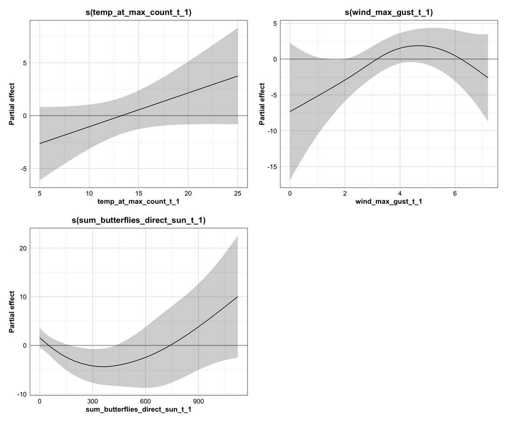

```r
# Create effect plots for the best model
# Extract which terms are in the best model
best_formula <- aic_results$Formula[1]
has_smooth <- grepl("s\\(", best_formula)

if (has_smooth) {
    # For GAM with smooth terms
    plots <- list()

    # Check which smooth terms are in the model
    smooth_terms <- summary(best_model$gam)$s.table

    # Plot each smooth term
    for (i in 1:nrow(smooth_terms)) {
        term_name <- rownames(smooth_terms)[i]
        p <- draw(best_model$gam, select = term_name, rug = FALSE, residuals = FALSE) +
            custom_theme +
            theme(plot.caption = element_blank())
        p <- add_zero_line(p)
        plots[[i]] <- p
    }

    # Combine plots
    if (length(plots) > 0) {
        if (length(plots) <= 2) {
            combined_plots <- wrap_plots(plots, nrow = 1)
        } else if (length(plots) <= 4) {
            combined_plots <- wrap_plots(plots, nrow = 2)
        } else {
            combined_plots <- wrap_plots(plots, nrow = 3)
        }
        print(combined_plots)
    }
} else {
    # For linear models, create partial residual plots
    cat("Best model uses linear terms. Creating partial residual plots...\n")

    # Extract coefficients
    coef_summary <- summary(best_model$gam)$p.table
    print(coef_summary)
}
```

## Wind Effect Analysis

```r
# Check if wind is in the best model
has_wind <- grepl("wind_max_gust", best_formula)

if (has_wind) {
    cat("Wind is included in the best model.\n\n")

    # Extract wind coefficient or smooth term details
    if (grepl("s\\(wind_max_gust", best_formula)) {
        # Smooth term
        smooth_table <- summary(best_model$gam)$s.table
        wind_row <- grep("wind_max_gust", rownames(smooth_table))

        if (length(wind_row) > 0) {
            wind_smooth <- smooth_table[wind_row[1], ]
            cat("Wind effect (smooth term):\n")
            cat("EDF:", round(wind_smooth["edf"], 3), "\n")
            cat("F-statistic:", round(wind_smooth["F"], 3), "\n")
            cat("p-value:", format.pval(wind_smooth["p-value"], digits = 3), "\n")
        }
    } else {
        # Linear term
        param_table <- summary(best_model$gam)$p.table
        wind_row <- grep("wind_max_gust", rownames(param_table))

        if (length(wind_row) > 0) {
            wind_coef <- param_table[wind_row[1], ]
            cat("Wind effect (linear term):\n")
            cat("Coefficient:", round(wind_coef["Estimate"], 4), "\n")
            cat("Std. Error:", round(wind_coef["Std. Error"], 4), "\n")
            cat("t-value:", round(wind_coef["t value"], 3), "\n")
            cat("p-value:", format.pval(wind_coef["Pr(>|t|)"], digits = 3), "\n")
        }
    }
} else {
    cat("Wind is NOT included in the best model.\n")
    cat("Testing wind effect by comparing models with and without wind...\n\n")

    # Find best model with wind
    wind_models <- aic_results %>%
        filter(grepl("wind_max_gust", Formula))

    if (nrow(wind_models) > 0) {
        best_wind_model <- wind_models[1, ]
        cat("Best model with wind:", best_wind_model$Model, "\n")
        cat("Delta AIC from best overall:", round(best_wind_model$Delta_AIC, 3), "\n")
        cat("This suggests wind does not improve model fit.\n")
    }
}
```

```
Wind is included in the best model.

Wind effect (smooth term):
EDF: 2.561
F-statistic: 3.614
p-value: 0.0447
```

## Temperature Effects Analysis

```r
# Analyze temperature effects in the best model
temp_vars <- c("temp_max_t_1", "temp_min_t_1", "temp_at_max_count_t_1")
temp_in_model <- sapply(temp_vars, function(x) grepl(x, best_formula))

cat("Temperature variables in best model:\n")
```

```
Temperature variables in best model:
```

```r
for (i in 1:length(temp_vars)) {
    if (temp_in_model[i]) {
        cat("-", temp_vars[i], "\n")
    }
}
```

```
- temp_at_max_count_t_1
```

```r
# If temperature is in the model, show its effect
if (any(temp_in_model)) {
    cat("\nTemperature effects:\n")

    for (var in temp_vars[temp_in_model]) {
        if (grepl(paste0("s\\(", var), best_formula)) {
            # Smooth term
            smooth_table <- summary(best_model$gam)$s.table
            smooth_name <- paste0("s(", var, ")")

            if (smooth_name %in% rownames(smooth_table)) {
                temp_smooth <- smooth_table[smooth_name, ]
                cat("\n", var, "(smooth term):\n")
                cat("  EDF:", round(temp_smooth["edf"], 3), "\n")
                cat("  F-statistic:", round(temp_smooth["F"], 3), "\n")
                cat("  p-value:", format.pval(temp_smooth["p-value"], digits = 3), "\n")
            }
        } else if (var %in% rownames(summary(best_model$gam)$p.table)) {
            # Linear term
            param_table <- summary(best_model$gam)$p.table
            temp_coef <- param_table[var, ]
            cat("\n", var, "(linear term):\n")
            cat("  Coefficient:", round(temp_coef["Estimate"], 4), "\n")
            cat("  Std. Error:", round(temp_coef["Std. Error"], 4), "\n")
            cat("  t-value:", round(temp_coef["t value"], 3), "\n")
            cat("  p-value:", format.pval(temp_coef["Pr(>|t|)"], digits = 3), "\n")
        }
    }
}
```

```
Temperature effects:

 temp_at_max_count_t_1 (smooth term):
  EDF: 1
  F-statistic: 3.003
  p-value: 0.0864
```

## Model Diagnostics

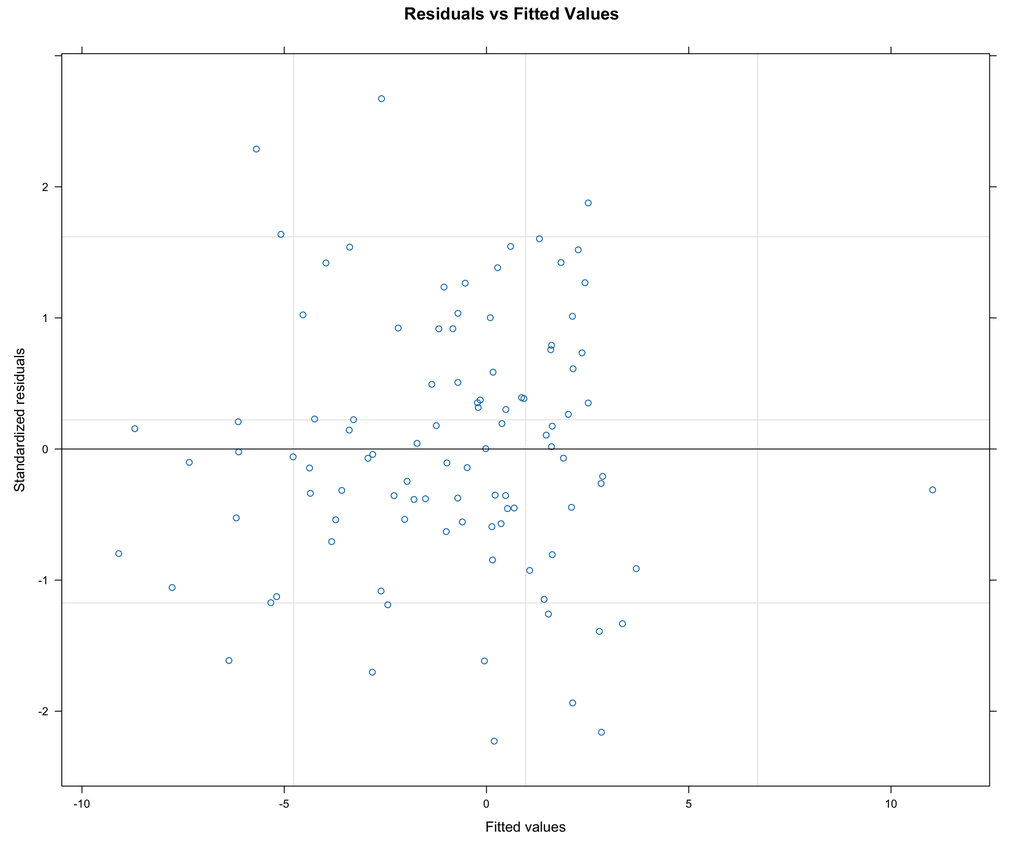

```r
# Create diagnostic plots
par(mfrow = c(2, 2))

# Residuals vs Fitted
plot(best_model$lme, main = "Residuals vs Fitted Values")
```

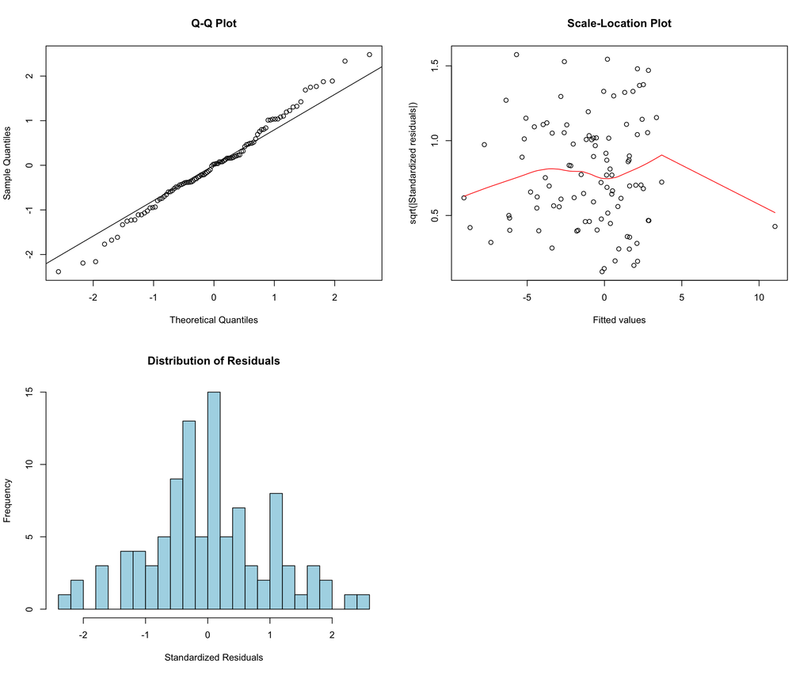

```r
# Q-Q plot
qqnorm(residuals(best_model$lme, type = "normalized"), main = "Q-Q Plot")
qqline(residuals(best_model$lme, type = "normalized"))

# Scale-location plot
plot(fitted(best_model$lme), sqrt(abs(residuals(best_model$lme, type = "normalized"))),
    main = "Scale-Location Plot",
    xlab = "Fitted values",
    ylab = "sqrt(|Standardized residuals|)"
)
lines(lowess(fitted(best_model$lme), sqrt(abs(residuals(best_model$lme, type = "normalized")))), col = "red")

# Histogram of residuals
hist(residuals(best_model$lme, type = "normalized"),
    breaks = 30,
    main = "Distribution of Residuals",
    xlab = "Standardized Residuals",
    col = "lightblue"
)

par(mfrow = c(1, 1))
```

## Outlier Investigation

```r
# First, let's examine extreme values in our data before fitting models
cat("Response variable summary:\n")
```

```
Response variable summary:
```

```r
print(summary(model_data$butterfly_diff_95th_sqrt))
```

```
    Min.  1st Qu.   Median     Mean  3rd Qu.     Max.
-17.6068  -5.7489  -1.7248  -0.8095   4.4219  16.0187
```

```r
cat("\nExtremes in response variable:\n")
```

```
Extremes in response variable:
```

```r
print(quantile(model_data$butterfly_diff_95th_sqrt, c(0.001, 0.01, 0.05, 0.95, 0.99, 0.999), na.rm = TRUE))
```

```
     0.1%        1%        5%       95%       99%     99.9%
-17.38138 -15.35248 -13.55386  11.37729  15.59117  15.97598
```

```r
# Identify the most extreme observations
extreme_high <- model_data %>%
    arrange(desc(butterfly_diff_95th_sqrt)) %>%
    head(5) %>%
    select(deployment_id, date_t, butterfly_diff_95th_sqrt,
           butterflies_95th_percentile_t, butterflies_95th_percentile_t_1,
           temp_max_t_1, wind_max_gust_t_1)

extreme_low <- model_data %>%
    arrange(butterfly_diff_95th_sqrt) %>%
    head(5) %>%
    select(deployment_id, date_t, butterfly_diff_95th_sqrt,
           butterflies_95th_percentile_t, butterflies_95th_percentile_t_1,
           temp_max_t_1, wind_max_gust_t_1)

cat("\nTop 5 most extreme HIGH values:\n")
```

```
Top 5 most extreme HIGH values:
```

```r
print(extreme_high)
```

```
# A tibble: 5 × 7
  deployment_id date_t     butterfly_diff_95th_sqrt butterflies_95th_percentil…¹
  <chr>         <date>                        <dbl>                        <dbl>
1 SC10          2024-01-12                     16.0                         477.
2 SC10          2024-01-23                     15.6                         246.
3 SC4           2023-12-07                     12.8                         170.
4 SC4           2023-12-24                     12.5                         263
5 SC6           2024-01-01                     11.7                         164
# ℹ abbreviated name: ¹butterflies_95th_percentile_t
# ℹ 3 more variables: butterflies_95th_percentile_t_1 <dbl>,
#   temp_max_t_1 <dbl>, wind_max_gust_t_1 <dbl>
```

```r
cat("\nTop 5 most extreme LOW values:\n")
```

```
Top 5 most extreme LOW values:
```

```r
print(extreme_low)
```

```
# A tibble: 5 × 7
  deployment_id date_t     butterfly_diff_95th_sqrt butterflies_95th_percentil…¹
  <chr>         <date>                        <dbl>                        <dbl>
1 SC4           2023-12-05                    -17.6                        187
2 SC8           2024-01-18                    -15.3                         53
3 SC4           2023-12-10                    -15.1                         19
4 SC10          2024-01-15                    -14.7                        283.
5 SC10          2024-01-16                    -14.6                         68.9
# ℹ abbreviated name: ¹butterflies_95th_percentile_t
# ℹ 3 more variables: butterflies_95th_percentile_t_1 <dbl>,
#   temp_max_t_1 <dbl>, wind_max_gust_t_1 <dbl>
```

```r
# Check if extreme values correspond to specific deployments
cat("\nExtreme values by deployment:\n")
```

```
Extreme values by deployment:
```

```r
extreme_summary <- model_data %>%
    group_by(deployment_id) %>%
    summarise(
        n_obs = n(),
        min_change = min(butterfly_diff_95th_sqrt),
        max_change = max(butterfly_diff_95th_sqrt),
        range_change = max_change - min_change,
        .groups = 'drop'
    ) %>%
    arrange(desc(range_change))

print(head(extreme_summary, 10))
```

```
# A tibble: 6 × 5
  deployment_id n_obs min_change max_change range_change
  <chr>         <int>      <dbl>      <dbl>        <dbl>
1 SC10             21     -14.7       16.0         30.7
2 SC4              31     -17.6       12.8         30.5
3 SC6              20     -12.2       11.7         24.0
4 SC8              20     -15.3        7.55        22.9
5 SC12              6     -10.2        8.29        18.4
6 SC1               2      -5.92      -3.99         1.93
```

## Sensitivity Analysis

```r
# Test model sensitivity to outliers
# Identify potential outliers
residuals_std <- residuals(best_model$lme, type = "normalized")
outliers <- which(abs(residuals_std) > 3)

if (length(outliers) > 0) {
    cat("Number of potential outliers (|standardized residual| > 3):", length(outliers), "\n")
    cat("Proportion of data:", round(length(outliers) / nrow(model_data) * 100, 2), "%\n\n")

    # Refit without outliers
    model_data_clean <- model_data[-outliers, ]
    best_model_clean <- fit_model_safely(aic_results$Formula[1], model_data_clean)

    if (!is.null(best_model_clean)) {
        cat("Model comparison with outliers removed:\n")
        cat("Original R²:", round(summary(best_model$gam)$r.sq, 4), "\n")
        cat("Without outliers R²:", round(summary(best_model_clean$gam)$r.sq, 4), "\n")
    }
} else {
    cat("No extreme outliers detected (|standardized residual| > 3)\n")
}
```

```
No extreme outliers detected (|standardized residual| > 3)
```

## Correlation Structure Diagnostics

```r
# Investigate potential issues with correlation structures
cat("Investigating correlation structure issues...\n\n")
```

```
Investigating correlation structure issues...
```

```r
# Check data structure for correlation modeling
cat("Data structure for temporal correlation:\n")
```

```
Data structure for temporal correlation:
```

```r
temporal_structure <- model_data %>%
    group_by(deployment_id) %>%
    summarise(
        n_days = n(),
        date_range = paste(min(date_t), "to", max(date_t)),
        day_sequence_range = paste(min(day_sequence), "to", max(day_sequence)),
        .groups = 'drop'
    ) %>%
    arrange(desc(n_days))

print(head(temporal_structure, 10))
```

```
# A tibble: 6 × 4
  deployment_id n_days date_range               day_sequence_range
  <chr>          <int> <chr>                    <chr>
1 SC4               31 2023-12-05 to 2024-01-05 17 to 48
2 SC10              21 2024-01-07 to 2024-01-30 50 to 73
3 SC6               20 2023-12-17 to 2024-01-05 29 to 48
4 SC8               20 2024-01-07 to 2024-01-26 50 to 69
5 SC12               6 2024-01-29 to 2024-02-03 72 to 77
6 SC1                2 2023-11-19 to 2023-11-20 1 to 2
```

```r
# Check if there are gaps in the day sequences that could cause issues
cat("\nChecking for gaps in day sequences within deployments:\n")
```

```
Checking for gaps in day sequences within deployments:
```

```r
gap_check <- model_data %>%
    arrange(deployment_id, day_sequence) %>%
    group_by(deployment_id) %>%
    mutate(
        day_diff = c(NA, diff(day_sequence)),
        has_gap = day_diff > 1
    ) %>%
    filter(has_gap, .preserve = TRUE) %>%
    summarise(
        n_gaps = sum(has_gap, na.rm = TRUE),
        max_gap = max(day_diff, na.rm = TRUE),
        .groups = 'drop'
    )

if (nrow(gap_check) > 0) {
    print(gap_check)
    cat("\nGaps in day sequences detected - this could cause issues with temporal correlation!\n")
} else {
    cat("No gaps detected in day sequences within deployments.\n")
}
```

```
# A tibble: 6 × 3
  deployment_id n_gaps max_gap
  <chr>          <int>   <dbl>
1 SC1                0    -Inf
2 SC10               2       3
3 SC12               0    -Inf
4 SC4                1       2
5 SC6                0    -Inf
6 SC8                0    -Inf

Gaps in day sequences detected - this could cause issues with temporal correlation!
```

```r
# Compare simple models with different correlation structures
cat("\nComparing simple null model with different correlation structures:\n")
```

```
Comparing simple null model with different correlation structures:
```

```r
simple_models <- list()

# Fit null model with each correlation structure
for (corr_name in names(correlation_structures)) {
    corr_struct <- correlation_structures[[corr_name]]

    simple_models[[corr_name]] <- tryCatch({
        if (is.null(corr_struct)) {
            gamm(butterfly_diff_95th_sqrt ~ 1,
                data = model_data,
                random = random_structure,
                method = "REML"
            )
        } else {
            gamm(butterfly_diff_95th_sqrt ~ 1,
                data = model_data,
                random = random_structure,
                correlation = corr_struct,
                method = "REML"
            )
        }
    }, error = function(e) {
        cat("Failed to fit null model with", corr_name, ":", e$message, "\n")
        return(NULL)
    })
}

# Compare AICs of simple models
simple_comparison <- map_dfr(names(simple_models), function(name) {
    model <- simple_models[[name]]
    if (!is.null(model)) {
        data.frame(
            Correlation = name,
            AIC = AIC(model$lme),
            LogLik = as.numeric(logLik(model$lme)),
            stringsAsFactors = FALSE
        )
    }
}) %>%
    arrange(AIC) %>%
    mutate(Delta_AIC = AIC - min(AIC))

print(simple_comparison)
```

```
   Correlation      AIC    LogLik  Delta_AIC
1 ar1_compound 689.2205 -340.6102 0.00000000
2          ar1 689.2348 -340.6174 0.01434155
3      no_corr 689.8900 -341.9450 0.66950416
```

## Alternative Model Exploration

```r
# Examine top 3 models for consistency
cat("Examining top 3 models for consistency of effects:\n\n")
```

```
Examining top 3 models for consistency of effects:
```

```r
for (i in 1:min(3, nrow(aic_results))) {
    model_name <- aic_results$Model[i]
    model <- successful_models[[model_name]]

    cat("Model", i, "(", model_name, "):\n")
    cat("Formula:", aic_results$Formula[i], "\n")
    cat("Delta AIC:", round(aic_results$Delta_AIC[i], 3), "\n")
    cat("R²:", round(summary(model$gam)$r.sq, 4), "\n\n")
}
```

```
Model 1 ( M34_ar1 ):
Formula: butterfly_diff_95th_sqrt ~ s(temp_at_max_count_t_1) + s(wind_max_gust_t_1) + s(sum_butterflies_direct_sun_t_1)
Delta AIC: 0
R²: 0.1347

Model 2 ( M36_ar1 ):
Formula: butterfly_diff_95th_sqrt ~ s(temp_at_max_count_t_1) + s(wind_max_gust_t_1) + s(sum_butterflies_direct_sun_t_1)
Delta AIC: 0
R²: 0.1347

Model 3 ( M33_ar1 ):
Formula: butterfly_diff_95th_sqrt ~ s(wind_max_gust_t_1) + s(sum_butterflies_direct_sun_t_1)
Delta AIC: 0.056
R²: 0.1093
```

## Results Summary

```r
cat(rep("=", 60), collapse = "", "\n")
cat("DAILY LAG ANALYSIS SUMMARY\n")
```

```
DAILY LAG ANALYSIS SUMMARY
```

```r
cat(rep("=", 60), collapse = "", "\n\n")
cat("Dataset:\n")
```

```
Dataset:
```

```r
cat("- Total observations:", nrow(model_data), "\n")
```

```
- Total observations: 100
```

```r
cat("- Number of deployments:", n_distinct(model_data$deployment_id), "\n")
```

```
- Number of deployments: 6
```

```r
cat("- Date range:", min(model_data$date_t), "to", max(model_data$date_t), "\n\n")
```

```
- Date range: 19680 to 19756
```

```r
cat("Best Model:\n")
```

```
Best Model:
```

```r
cat("- Model ID:", best_model_name, "\n")
```

```
- Model ID: M34_ar1
```

```r
cat("- Formula:", aic_results$Formula[1], "\n")
```

```
- Formula: butterfly_diff_95th_sqrt ~ s(temp_at_max_count_t_1) + s(wind_max_gust_t_1) + s(sum_butterflies_direct_sun_t_1)
```

```r
cat("- AIC:", round(aic_results$AIC[1], 3), "\n")
```

```
- AIC: 682.468
```

```r
cat("- R-squared:", round(r_squared, 4), "\n")
```

```
- R-squared: 0.1347
```

```r
cat("- Deviance explained:", round(dev_explained * 100, 2), "%\n\n")
```

```
- Deviance explained:  %
```

```r
cat("Key Findings:\n")
```

```
Key Findings:
```

```r
# Wind effect
if (has_wind) {
    cat("- Wind IS included in the best model\n")
    if (grepl("s\\(wind_max_gust", best_formula)) {
        wind_p <- summary(best_model$gam)$s.table["s(wind_max_gust_t_1)", "p-value"]
        cat("  - Effect type: Non-linear (smooth)\n")
        cat("  - Significance: p =", format.pval(wind_p, digits = 3), "\n")
    } else {
        wind_p <- summary(best_model$gam)$p.table["wind_max_gust_t_1", "Pr(>|t|)"]
        cat("  - Effect type: Linear\n")
        cat("  - Significance: p =", format.pval(wind_p, digits = 3), "\n")
    }
} else {
    cat("- Wind is NOT included in the best model\n")
    wind_models <- aic_results %>% filter(grepl("wind_max_gust", Formula))
    if (nrow(wind_models) > 0) {
        cat("  - Best model with wind has Delta AIC =", round(wind_models$Delta_AIC[1], 3), "\n")
    }
}
```

```
- Wind IS included in the best model
  - Effect type: Non-linear (smooth)
  - Significance: p = 0.0447
```

```r
# Temperature effects
if (any(temp_in_model)) {
    cat("\n- Temperature effects:\n")
    for (var in temp_vars[temp_in_model]) {
        cat("  -", var, "is included\n")
    }
} else {
    cat("\n- No temperature variables in the best model\n")
}
```

```
- Temperature effects:
  - temp_at_max_count_t_1 is included
```

```r
# Other predictors
if (grepl("sum_butterflies_direct_sun", best_formula)) {
    cat("\n- Sun exposure IS included in the best model\n")
}
```

```
- Sun exposure IS included in the best model
```

```r
if (grepl("butterflies_95th_percentile_t_1", best_formula)) {
    cat("- Previous day baseline IS included in the best model\n")
} else {
    cat("- Previous day baseline is NOT in the model (testing absolute effects)\n")
}
```

```
- Previous day baseline is NOT in the model (testing absolute effects)
```

```r
# Temporal autocorrelation is handled in the random structure
best_correlation <- aic_results$Correlation[1]
cat("- Temporal autocorrelation: Best model uses", best_correlation, "correlation structure\n")
```

```
- Temporal autocorrelation: Best model uses ar1 correlation structure
```

```r
if (best_correlation != "no_corr") {
    cat("  - This indicates significant temporal autocorrelation in residuals\n")
} else {
    cat("  - No significant temporal autocorrelation detected\n")
}
```

```
  - This indicates significant temporal autocorrelation in residuals
```

```r
cat("\n", rep("=", 60), collapse = "", "\n")
```

## Export Results

```r
# Create export directory
export_dir <- here("thesis_exports", "daily_analysis")
if (!dir.exists(export_dir)) dir.create(export_dir, recursive = TRUE)

# Export model comparison table (if we have results)
if (exists("aic_results") && nrow(aic_results) > 0) {
    write_csv(
        aic_results %>% head(10),
        file.path(export_dir, "daily_model_comparison.csv")
    )

    # Export best model summary
    best_model_summary <- data.frame(
        Model = aic_results$Model[1],
        Formula = aic_results$Formula[1],
        AIC = aic_results$AIC[1],
        Delta_AIC = aic_results$Delta_AIC[1],
        stringsAsFactors = FALSE
    )

    write_csv(
        best_model_summary,
        file.path(export_dir, "daily_best_model_summary.csv")
    )

    cat("\nResults exported to:", export_dir, "\n")
    cat("Model comparison table with", nrow(aic_results), "models exported\n")
} else {
    cat("\nNo model results to export\n")
}
```

```
Results exported to: /Users/kylenessen/Documents/Code/masters-analysis/thesis_exports/daily_analysis
Model comparison table with 138 models exported
```

## Conclusions

This daily-level analysis examined the **absolute effects** of previous day’s weather conditions on monarch butterfly abundance changes, measured as the 95th percentile of counts. Importantly, this analysis deliberately excludes the previous day’s butterfly count to test direct environmental effects rather than proportional changes. Temporal patterns are modeled through autocorrelation structures in the random effects rather than as fixed effects.

The analysis of absolute effects provides important insights into whether environmental variables have fixed magnitude effects on butterfly abundance or whether their effects scale with population size.